# **Problem Statement**

## **Business Context**

Workplace safety in hazardous environments like construction sites and industrial plants is crucial to prevent accidents and injuries. One of the most important safety measures is ensuring workers wear safety helmets, which protect against head injuries from falling objects and machinery. Non-compliance with helmet regulations increases the risk of serious injuries or fatalities, making effective monitoring essential, especially in large-scale operations where manual oversight is prone to errors and inefficiency.

To overcome these challenges, SafeGuard Corp plans to develop an automated image analysis system capable of detecting whether workers are wearing safety helmets. This system will improve safety enforcement, ensuring compliance and reducing the risk of head injuries. By automating helmet monitoring, SafeGuard aims to enhance efficiency, scalability, and accuracy, ultimately fostering a safer work environment while minimizing human error in safety oversight.

## **Objective**

As a data scientist at SafeGuard Corp, you are tasked with developing an image classification model that classifies images into one of two categories:

- **With Helmet:** Workers wearing safety helmets.
- **Without Helmet:** Workers not wearing safety helmets.

## **Data Description**

The dataset consists of **631 images**, equally divided into two categories:

- **With Helmet:** 311 images showing workers wearing helmets.
- **Without Helmet:** 320 images showing workers not wearing helmets.

**Dataset Characteristics:**

- **Variations in Conditions:** Images include diverse environments such as construction sites, factories, and industrial settings, with variations in lighting, angles, and worker postures to simulate real-world conditions.
- **Worker Activities:** Workers are depicted in different actions such as standing, using tools, or moving, ensuring robust model learning for various scenarios.

# **Installing and Importing the Necessary Libraries**

[output not shown]

```
Num GPUs Available: 0
2.17.1
```

**Note:**

- After running the above cell, kindly restart the notebook kernel (for Jupyter Notebook) or runtime (for Google Colab) and run all cells sequentially from the next cell.
- On executing the above line of code, you might see a warning regarding package dependencies. This error message can be ignored as the above code ensures that all necessary libraries and their dependencies are maintained to successfully execute the code in this notebook.

# **Data Overview**

## Loading the data

# **Exploratory Data Analysis**

### Plot random images from each of the classes and print their corresponding labels.

[figure not shown]

## Checking for class imbalance

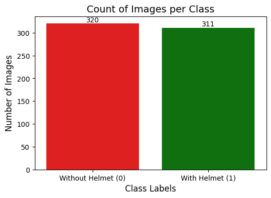

# **Data Preprocessing**

## Converting images to grayscale

[figure not shown]

### Splitting the dataset

```
(441, 200, 200, 3) (441, 1)
(95, 200, 200, 3) (95, 1)
(95, 200, 200, 3) (95, 1)
```

### Data Normalization

# **Model Building**

## Model Evaluation Criterion

## Utility Functions

## Model 1: Simple Convolutional Neural Network (CNN)

```
Model: "sequential"
```

```
┏━━━━━━━━━━━━━━━━━━━━━━━━━━━━━━━━━┳━━━━━━━━━━━━━━━━━━━━━━━━┳━━━━━━━━━━━━━━━┓
┃ Layer (type)                    ┃ Output Shape           ┃       Param # ┃
┡━━━━━━━━━━━━━━━━━━━━━━━━━━━━━━━━━╇━━━━━━━━━━━━━━━━━━━━━━━━╇━━━━━━━━━━━━━━━┩
│ conv2d (Conv2D)                 │ (None, 200, 200, 32)   │           896 │
├─────────────────────────────────┼────────────────────────┼───────────────┤
│ max_pooling2d (MaxPooling2D)    │ (None, 50, 50, 32)     │             0 │
├─────────────────────────────────┼────────────────────────┼───────────────┤
│ conv2d_1 (Conv2D)               │ (None, 50, 50, 64)     │        18,496 │
├─────────────────────────────────┼────────────────────────┼───────────────┤
│ max_pooling2d_1 (MaxPooling2D)  │ (None, 25, 25, 64)     │             0 │
├─────────────────────────────────┼────────────────────────┼───────────────┤
│ conv2d_2 (Conv2D)               │ (None, 25, 25, 128)    │        73,856 │
├─────────────────────────────────┼────────────────────────┼───────────────┤
│ flatten (Flatten)               │ (None, 80000)          │             0 │
├─────────────────────────────────┼────────────────────────┼───────────────┤
│ dense (Dense)                   │ (None, 4)              │       320,004 │
├─────────────────────────────────┼────────────────────────┼───────────────┤
│ dense_1 (Dense)                 │ (None, 1)              │             5 │
└─────────────────────────────────┴────────────────────────┴───────────────┘
```

```
 Total params: 413,257 (1.58 MB)
```

```
 Trainable params: 413,257 (1.58 MB)
```

```
 Non-trainable params: 0 (0.00 B)
```

```
14/14 - 21s - 1s/step - Precision: 0.4624 - accuracy: 0.4921 - loss: 0.7896 - val_Precision: 0.0000e+00 - val_accuracy: 0.5053 - val_loss: 0.6896
14/14 - 19s - 1s/step - Precision: 0.0000e+00 - accuracy: 0.5079 - loss: 0.6698 - val_Precision: 0.0000e+00 - val_accuracy: 0.5053 - val_loss: 0.6073
14/14 - 16s - 1s/step - Precision: 0.9655 - accuracy: 0.5692 - loss: 0.4746 - val_Precision: 1.0000 - val_accuracy: 0.9684 - val_loss: 0.3213
14/14 - 20s - 1s/step - Precision: 0.9265 - accuracy: 0.9025 - loss: 0.3700 - val_Precision: 0.7121 - val_accuracy: 0.8000 - val_loss: 0.4194
14/14 - 18s - 1s/step - Precision: 0.9552 - accuracy: 0.9683 - loss: 0.2103 - val_Precision: 0.9792 - val_accuracy: 0.9895 - val_loss: 0.0705
14/14 - 21s - 1s/step - Precision: 0.9954 - accuracy: 0.9955 - loss: 0.0591 - val_Precision: 1.0000 - val_accuracy: 0.9684 - val_loss: 0.0662
14/14 - 19s - 1s/step - Precision: 0.9904 - accuracy: 0.9728 - loss: 0.0978 - val_Precision: 1.0000 - val_accuracy: 0.9684 - val_loss: 0.0452
14/14 - 16s - 1s/step - Precision: 0.9952 - accuracy: 0.9751 - loss: 0.0712 - val_Precision: 0.9792 - val_accuracy: 0.9895 - val_loss: 0.0807
14/14 - 21s - 1s/step - Precision: 1.0000 - accuracy: 0.9864 - loss: 0.0469 - val_Precision: 0.9792 - val_accuracy: 0.9895 - val_loss: 0.0841
14/14 - 16s - 1s/step - Precision: 1.0000 - accuracy: 1.0000 - loss: 0.0134 - val_Precision: 0.9792 - val_accuracy: 0.9895 - val_loss: 0.1042
14/14 - 16s - 1s/step - Precision: 1.0000 - accuracy: 1.0000 - loss: 0.0011 - val_Precision: 0.9792 - val_accuracy: 0.9895 - val_loss: 0.1930
14/14 - 21s - 1s/step - Precision: 1.0000 - accuracy: 1.0000 - loss: 1.0802e-04 - val_Precision: 0.9792 - val_accuracy: 0.9895 - val_loss: 0.1451
14/14 - 20s - 1s/step - Precision: 1.0000 - accuracy: 1.0000 - loss: 3.3405e-05 - val_Precision: 0.9792 - val_accuracy: 0.9895 - val_loss: 0.1339
14/14 - 16s - 1s/step - Precision: 1.0000 - accuracy: 1.0000 - loss: 2.1256e-05 - val_Precision: 0.9792 - val_accuracy: 0.9895 - val_loss: 0.1474
14/14 - 16s - 1s/step - Precision: 1.0000 - accuracy: 1.0000 - loss: 1.5680e-05 - val_Precision: 0.9792 - val_accuracy: 0.9895 - val_loss: 0.1553
14/14 - 16s - 1s/step - Precision: 1.0000 - accuracy: 1.0000 - loss: 1.3346e-05 - val_Precision: 0.9792 - val_accuracy: 0.9895 - val_loss: 0.1585
14/14 - 21s - 1s/step - Precision: 1.0000 - accuracy: 1.0000 - loss: 1.1719e-05 - val_Precision: 0.9792 - val_accuracy: 0.9895 - val_loss: 0.1599
14/14 - 18s - 1s/step - Precision: 1.0000 - accuracy: 1.0000 - loss: 1.0407e-05 - val_Precision: 0.9792 - val_accuracy: 0.9895 - val_loss: 0.1607
14/14 - 19s - 1s/step - Precision: 1.0000 - accuracy: 1.0000 - loss: 9.3122e-06 - val_Precision: 0.9792 - val_accuracy: 0.9895 - val_loss: 0.1613
14/14 - 16s - 1s/step - Precision: 1.0000 - accuracy: 1.0000 - loss: 8.4271e-06 - val_Precision: 0.9792 - val_accuracy: 0.9895 - val_loss: 0.1608
```

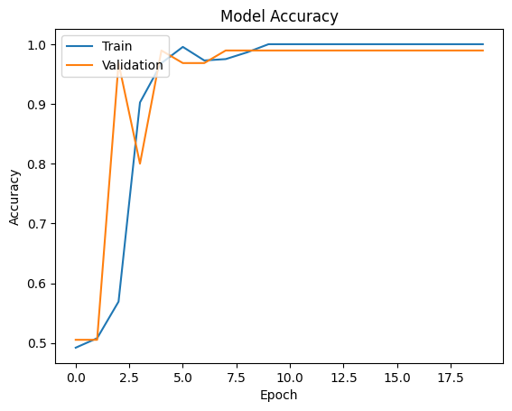

```
14/14 ━━━━━━━━━━━━━━━━━━━━ 5s 314ms/step
Train performance metrics
   Accuracy  Recall  Precision  F1 Score
0       1.0     1.0        1.0       1.0
```

```
14/14 ━━━━━━━━━━━━━━━━━━━━ 6s 437ms/step
```

```
3/3 ━━━━━━━━━━━━━━━━━━━━ 1s 332ms/step
Validation performance metrics
   Accuracy    Recall  Precision  F1 Score
0  0.989474  0.989474   0.989693  0.989474
```

```
3/3 ━━━━━━━━━━━━━━━━━━━━ 2s 504ms/step
```

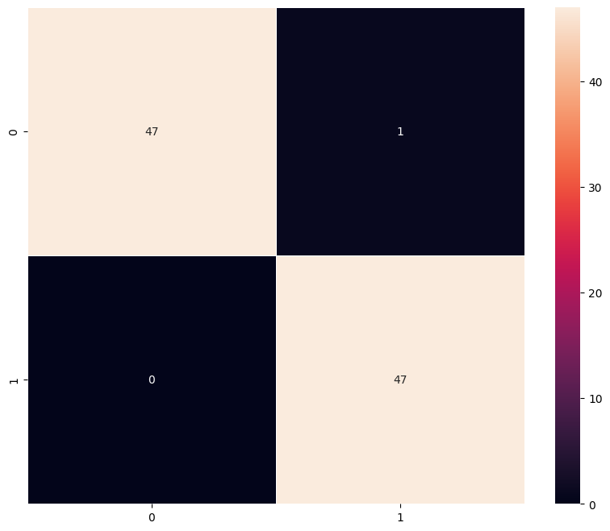

### Vizualizing the predictions

```
1/1 ━━━━━━━━━━━━━━━━━━━━ 0s 53ms/step
Predicted Label: 1
True Label: Label    1
Name: 173, dtype: int64
```

```
1/1 ━━━━━━━━━━━━━━━━━━━━ 0s 47ms/step
Predicted Label: 0
True Label: Label    0
Name: 462, dtype: int64
```

## Model 2: (VGG-16 (Base))

```
Model: "vgg16"
```

```
┏━━━━━━━━━━━━━━━━━━━━━━━━━━━━━━━━━┳━━━━━━━━━━━━━━━━━━━━━━━━┳━━━━━━━━━━━━━━━┓
┃ Layer (type)                    ┃ Output Shape           ┃       Param # ┃
┡━━━━━━━━━━━━━━━━━━━━━━━━━━━━━━━━━╇━━━━━━━━━━━━━━━━━━━━━━━━╇━━━━━━━━━━━━━━━┩
│ input_layer_1 (InputLayer)      │ (None, 200, 200, 3)    │             0 │
├─────────────────────────────────┼────────────────────────┼───────────────┤
│ block1_conv1 (Conv2D)           │ (None, 200, 200, 64)   │         1,792 │
├─────────────────────────────────┼────────────────────────┼───────────────┤
│ block1_conv2 (Conv2D)           │ (None, 200, 200, 64)   │        36,928 │
├─────────────────────────────────┼────────────────────────┼───────────────┤
│ block1_pool (MaxPooling2D)      │ (None, 100, 100, 64)   │             0 │
├─────────────────────────────────┼────────────────────────┼───────────────┤
│ block2_conv1 (Conv2D)           │ (None, 100, 100, 128)  │        73,856 │
├─────────────────────────────────┼────────────────────────┼───────────────┤
│ block2_conv2 (Conv2D)           │ (None, 100, 100, 128)  │       147,584 │
├─────────────────────────────────┼────────────────────────┼───────────────┤
│ block2_pool (MaxPooling2D)      │ (None, 50, 50, 128)    │             0 │
├─────────────────────────────────┼────────────────────────┼───────────────┤
│ block3_conv1 (Conv2D)           │ (None, 50, 50, 256)    │       295,168 │
├─────────────────────────────────┼────────────────────────┼───────────────┤
│ block3_conv2 (Conv2D)           │ (None, 50, 50, 256)    │       590,080 │
├─────────────────────────────────┼────────────────────────┼───────────────┤
│ block3_conv3 (Conv2D)           │ (None, 50, 50, 256)    │       590,080 │
├─────────────────────────────────┼────────────────────────┼───────────────┤
│ block3_pool (MaxPooling2D)      │ (None, 25, 25, 256)    │             0 │
├─────────────────────────────────┼────────────────────────┼───────────────┤
│ block4_conv1 (Conv2D)           │ (None, 25, 25, 512)    │     1,180,160 │
├─────────────────────────────────┼────────────────────────┼───────────────┤
│ block4_conv2 (Conv2D)           │ (None, 25, 25, 512)    │     2,359,808 │
├─────────────────────────────────┼────────────────────────┼───────────────┤
│ block4_conv3 (Conv2D)           │ (None, 25, 25, 512)    │     2,359,808 │
├─────────────────────────────────┼────────────────────────┼───────────────┤
│ block4_pool (MaxPooling2D)      │ (None, 12, 12, 512)    │             0 │
├─────────────────────────────────┼────────────────────────┼───────────────┤
│ block5_conv1 (Conv2D)           │ (None, 12, 12, 512)    │     2,359,808 │
├─────────────────────────────────┼────────────────────────┼───────────────┤
│ block5_conv2 (Conv2D)           │ (None, 12, 12, 512)    │     2,359,808 │
├─────────────────────────────────┼────────────────────────┼───────────────┤
│ block5_conv3 (Conv2D)           │ (None, 12, 12, 512)    │     2,359,808 │
├─────────────────────────────────┼────────────────────────┼───────────────┤
│ block5_pool (MaxPooling2D)      │ (None, 6, 6, 512)      │             0 │
└─────────────────────────────────┴────────────────────────┴───────────────┘
```

```
 Total params: 14,714,688 (56.13 MB)
```

```
 Trainable params: 14,714,688 (56.13 MB)
```

```
 Non-trainable params: 0 (0.00 B)
```

```
Model: "sequential_1"
```

```
┏━━━━━━━━━━━━━━━━━━━━━━━━━━━━━━━━━┳━━━━━━━━━━━━━━━━━━━━━━━━┳━━━━━━━━━━━━━━━┓
┃ Layer (type)                    ┃ Output Shape           ┃       Param # ┃
┡━━━━━━━━━━━━━━━━━━━━━━━━━━━━━━━━━╇━━━━━━━━━━━━━━━━━━━━━━━━╇━━━━━━━━━━━━━━━┩
│ vgg16 (Functional)              │ (None, 6, 6, 512)      │    14,714,688 │
├─────────────────────────────────┼────────────────────────┼───────────────┤
│ flatten_1 (Flatten)             │ (None, 18432)          │             0 │
├─────────────────────────────────┼────────────────────────┼───────────────┤
│ dense_2 (Dense)                 │ (None, 1)              │        18,433 │
└─────────────────────────────────┴────────────────────────┴───────────────┘
```

```
 Total params: 14,733,121 (56.20 MB)
```

```
 Trainable params: 18,433 (72.00 KB)
```

```
 Non-trainable params: 14,714,688 (56.13 MB)
```

```
13/13 ━━━━━━━━━━━━━━━━━━━━ 216s 17s/step - accuracy: 0.7291 - loss: 0.6187 - val_accuracy: 0.9684 - val_loss: 0.4239
13/13 ━━━━━━━━━━━━━━━━━━━━ 53s 3s/step - accuracy: 1.0000 - loss: 0.4270 - val_accuracy: 0.9684 - val_loss: 0.4074
13/13 ━━━━━━━━━━━━━━━━━━━━ 260s 16s/step - accuracy: 0.9937 - loss: 0.3320 - val_accuracy: 1.0000 - val_loss: 0.2542
13/13 ━━━━━━━━━━━━━━━━━━━━ 54s 3s/step - accuracy: 1.0000 - loss: 0.2471 - val_accuracy: 1.0000 - val_loss: 0.2461
13/13 ━━━━━━━━━━━━━━━━━━━━ 216s 17s/step - accuracy: 0.9949 - loss: 0.1997 - val_accuracy: 1.0000 - val_loss: 0.1692
13/13 ━━━━━━━━━━━━━━━━━━━━ 54s 3s/step - accuracy: 1.0000 - loss: 0.1583 - val_accuracy: 1.0000 - val_loss: 0.1650
13/13 ━━━━━━━━━━━━━━━━━━━━ 208s 16s/step - accuracy: 1.0000 - loss: 0.1374 - val_accuracy: 1.0000 - val_loss: 0.1250
13/13 ━━━━━━━━━━━━━━━━━━━━ 51s 3s/step - accuracy: 1.0000 - loss: 0.0987 - val_accuracy: 1.0000 - val_loss: 0.1227
13/13 ━━━━━━━━━━━━━━━━━━━━ 217s 17s/step - accuracy: 1.0000 - loss: 0.0979 - val_accuracy: 1.0000 - val_loss: 0.0993
13/13 ━━━━━━━━━━━━━━━━━━━━ 55s 3s/step - accuracy: 1.0000 - loss: 0.0810 - val_accuracy: 1.0000 - val_loss: 0.0979
13/13 ━━━━━━━━━━━━━━━━━━━━ 260s 17s/step - accuracy: 1.0000 - loss: 0.0793 - val_accuracy: 1.0000 - val_loss: 0.0827
13/13 ━━━━━━━━━━━━━━━━━━━━ 54s 3s/step - accuracy: 1.0000 - loss: 0.0540 - val_accuracy: 1.0000 - val_loss: 0.0817
13/13 ━━━━━━━━━━━━━━━━━━━━ 282s 17s/step - accuracy: 1.0000 - loss: 0.0677 - val_accuracy: 1.0000 - val_loss: 0.0709
13/13 ━━━━━━━━━━━━━━━━━━━━ 54s 3s/step - accuracy: 1.0000 - loss: 0.0474 - val_accuracy: 1.0000 - val_loss: 0.0702
13/13 ━━━━━━━━━━━━━━━━━━━━ 256s 16s/step - accuracy: 1.0000 - loss: 0.0540 - val_accuracy: 1.0000 - val_loss: 0.0623
```

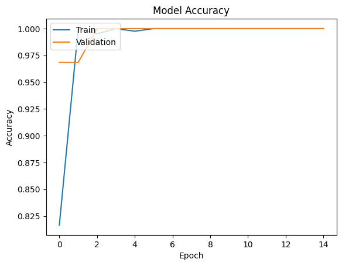

```
14/14 ━━━━━━━━━━━━━━━━━━━━ 192s 14s/step
Train performance metrics
   Accuracy  Recall  Precision  F1 Score
0       1.0     1.0        1.0       1.0
```

```
14/14 ━━━━━━━━━━━━━━━━━━━━ 182s 13s/step
```

```
3/3 ━━━━━━━━━━━━━━━━━━━━ 38s 13s/step
Validation performance metrics
   Accuracy  Recall  Precision  F1 Score
0       1.0     1.0        1.0       1.0
```

```
3/3 ━━━━━━━━━━━━━━━━━━━━ 39s 13s/step
```

### Visualizing the prediction:

```
1/1 ━━━━━━━━━━━━━━━━━━━━ 0s 386ms/step
Predicted Label: 1
True Label: Label    1
Name: 173, dtype: int64
```

```
1/1 ━━━━━━━━━━━━━━━━━━━━ 0s 405ms/step
Predicted Label: 0
True Label: Label    0
Name: 462, dtype: int64
```

## Model 3: (VGG-16 (Base + FFNN))

```
Model: "sequential_3"
```

```
┏━━━━━━━━━━━━━━━━━━━━━━━━━━━━━━━━━┳━━━━━━━━━━━━━━━━━━━━━━━━┳━━━━━━━━━━━━━━━┓
┃ Layer (type)                    ┃ Output Shape           ┃       Param # ┃
┡━━━━━━━━━━━━━━━━━━━━━━━━━━━━━━━━━╇━━━━━━━━━━━━━━━━━━━━━━━━╇━━━━━━━━━━━━━━━┩
│ vgg16 (Functional)              │ (None, 6, 6, 512)      │    14,714,688 │
├─────────────────────────────────┼────────────────────────┼───────────────┤
│ flatten_3 (Flatten)             │ (None, 18432)          │             0 │
├─────────────────────────────────┼────────────────────────┼───────────────┤
│ dense_6 (Dense)                 │ (None, 256)            │     4,718,848 │
├─────────────────────────────────┼────────────────────────┼───────────────┤
│ dropout_1 (Dropout)             │ (None, 256)            │             0 │
├─────────────────────────────────┼────────────────────────┼───────────────┤
│ dense_7 (Dense)                 │ (None, 128)            │        32,896 │
├─────────────────────────────────┼────────────────────────┼───────────────┤
│ dense_8 (Dense)                 │ (None, 1)              │           129 │
└─────────────────────────────────┴────────────────────────┴───────────────┘
```

```
 Total params: 19,466,561 (74.26 MB)
```

```
 Trainable params: 4,751,873 (18.13 MB)
```

```
 Non-trainable params: 14,714,688 (56.13 MB)
```

```
13/13 ━━━━━━━━━━━━━━━━━━━━ 223s 17s/step - accuracy: 0.7558 - loss: 0.4625 - val_accuracy: 1.0000 - val_loss: 0.0370
13/13 ━━━━━━━━━━━━━━━━━━━━ 95s 7s/step - accuracy: 1.0000 - loss: 0.0449 - val_accuracy: 1.0000 - val_loss: 0.0297
13/13 ━━━━━━━━━━━━━━━━━━━━ 212s 17s/step - accuracy: 1.0000 - loss: 0.0305 - val_accuracy: 1.0000 - val_loss: 0.0076
13/13 ━━━━━━━━━━━━━━━━━━━━ 54s 3s/step - accuracy: 1.0000 - loss: 0.0146 - val_accuracy: 1.0000 - val_loss: 0.0071
13/13 ━━━━━━━━━━━━━━━━━━━━ 214s 17s/step - accuracy: 1.0000 - loss: 0.0065 - val_accuracy: 1.0000 - val_loss: 0.0060
13/13 ━━━━━━━━━━━━━━━━━━━━ 95s 7s/step - accuracy: 1.0000 - loss: 0.0044 - val_accuracy: 1.0000 - val_loss: 0.0059
13/13 ━━━━━━━━━━━━━━━━━━━━ 225s 17s/step - accuracy: 1.0000 - loss: 0.0048 - val_accuracy: 1.0000 - val_loss: 0.0044
13/13 ━━━━━━━━━━━━━━━━━━━━ 54s 3s/step - accuracy: 1.0000 - loss: 0.0030 - val_accuracy: 1.0000 - val_loss: 0.0042
13/13 ━━━━━━━━━━━━━━━━━━━━ 270s 17s/step - accuracy: 1.0000 - loss: 0.0022 - val_accuracy: 1.0000 - val_loss: 0.0042
13/13 ━━━━━━━━━━━━━━━━━━━━ 53s 3s/step - accuracy: 1.0000 - loss: 9.8469e-04 - val_accuracy: 1.0000 - val_loss: 0.0042
13/13 ━━━━━━━━━━━━━━━━━━━━ 208s 16s/step - accuracy: 1.0000 - loss: 0.0023 - val_accuracy: 1.0000 - val_loss: 0.0045
13/13 ━━━━━━━━━━━━━━━━━━━━ 56s 3s/step - accuracy: 1.0000 - loss: 0.0014 - val_accuracy: 1.0000 - val_loss: 0.0046
13/13 ━━━━━━━━━━━━━━━━━━━━ 210s 16s/step - accuracy: 1.0000 - loss: 0.0013 - val_accuracy: 1.0000 - val_loss: 0.0030
13/13 ━━━━━━━━━━━━━━━━━━━━ 52s 3s/step - accuracy: 1.0000 - loss: 7.0245e-04 - val_accuracy: 1.0000 - val_loss: 0.0028
13/13 ━━━━━━━━━━━━━━━━━━━━ 310s 20s/step - accuracy: 1.0000 - loss: 0.0011 - val_accuracy: 1.0000 - val_loss: 0.0023
```

[figure not shown]

```
14/14 ━━━━━━━━━━━━━━━━━━━━ 217s 15s/step
Train performance metrics
   Accuracy  Recall  Precision  F1 Score
0       1.0     1.0        1.0       1.0
```

```
14/14 ━━━━━━━━━━━━━━━━━━━━ 185s 13s/step
```

```
3/3 ━━━━━━━━━━━━━━━━━━━━ 39s 13s/step
Validation performance metrics
   Accuracy  Recall  Precision  F1 Score
0       1.0     1.0        1.0       1.0
```

```
3/3 ━━━━━━━━━━━━━━━━━━━━ 40s 14s/step
```

#### Visualizing the predictions

```
1/1 ━━━━━━━━━━━━━━━━━━━━ 0s 383ms/step
Predicted Label: 1
True Label: Label    1
Name: 173, dtype: int64
```

```
1/1 ━━━━━━━━━━━━━━━━━━━━ 0s 406ms/step
Predicted Label: 0
True Label: Label    0
Name: 462, dtype: int64
```

## Model 4: (VGG-16 (Base + FFNN + Data Augmentation)

- In most of the real-world case studies, it is challenging to acquire a large number of images and then train CNNs.
- To overcome this problem, one approach we might consider is **Data Augmentation**.
- CNNs have the property of **translational invariance**, which means they can recognise an object even if its appearance shifts translationally in some way. - Taking this attribute into account, we can augment the images using the techniques listed below
  - Horizontal Flip (should be set to True/False)
  - Vertical Flip (should be set to True/False)
  - Height Shift (should be between 0 and 1)
  - Width Shift (should be between 0 and 1)
  - Rotation (should be between 0 and 180)
  - Shear (should be between 0 and 1)
  - Zoom (should be between 0 and 1) etc.

Remember, **data augmentation should not be used in the validation/test data set**.

```
Model: "sequential_4"
```

```
┏━━━━━━━━━━━━━━━━━━━━━━━━━━━━━━━━━┳━━━━━━━━━━━━━━━━━━━━━━━━┳━━━━━━━━━━━━━━━┓
┃ Layer (type)                    ┃ Output Shape           ┃       Param # ┃
┡━━━━━━━━━━━━━━━━━━━━━━━━━━━━━━━━━╇━━━━━━━━━━━━━━━━━━━━━━━━╇━━━━━━━━━━━━━━━┩
│ vgg16 (Functional)              │ (None, 6, 6, 512)      │    14,714,688 │
├─────────────────────────────────┼────────────────────────┼───────────────┤
│ flatten_4 (Flatten)             │ (None, 18432)          │             0 │
├─────────────────────────────────┼────────────────────────┼───────────────┤
│ dense_9 (Dense)                 │ (None, 256)            │     4,718,848 │
├─────────────────────────────────┼────────────────────────┼───────────────┤
│ dropout_2 (Dropout)             │ (None, 256)            │             0 │
├─────────────────────────────────┼────────────────────────┼───────────────┤
│ dense_10 (Dense)                │ (None, 128)            │        32,896 │
├─────────────────────────────────┼────────────────────────┼───────────────┤
│ dense_11 (Dense)                │ (None, 1)              │           129 │
└─────────────────────────────────┴────────────────────────┴───────────────┘
```

```
 Total params: 19,466,561 (74.26 MB)
```

```
 Trainable params: 4,751,873 (18.13 MB)
```

```
 Non-trainable params: 14,714,688 (56.13 MB)
```

```
13/13 ━━━━━━━━━━━━━━━━━━━━ 226s 17s/step - accuracy: 0.8034 - loss: 0.4231 - val_accuracy: 1.0000 - val_loss: 0.0436
13/13 ━━━━━━━━━━━━━━━━━━━━ 54s 3s/step - accuracy: 1.0000 - loss: 0.0592 - val_accuracy: 1.0000 - val_loss: 0.0414
13/13 ━━━━━━━━━━━━━━━━━━━━ 257s 17s/step - accuracy: 0.9944 - loss: 0.0416 - val_accuracy: 1.0000 - val_loss: 0.0098
13/13 ━━━━━━━━━━━━━━━━━━━━ 54s 3s/step - accuracy: 1.0000 - loss: 0.0406 - val_accuracy: 1.0000 - val_loss: 0.0084
13/13 ━━━━━━━━━━━━━━━━━━━━ 269s 17s/step - accuracy: 1.0000 - loss: 0.0093 - val_accuracy: 1.0000 - val_loss: 0.0035
13/13 ━━━━━━━━━━━━━━━━━━━━ 53s 3s/step - accuracy: 1.0000 - loss: 0.0094 - val_accuracy: 1.0000 - val_loss: 0.0034
13/13 ━━━━━━━━━━━━━━━━━━━━ 270s 17s/step - accuracy: 1.0000 - loss: 0.0080 - val_accuracy: 1.0000 - val_loss: 0.0041
13/13 ━━━━━━━━━━━━━━━━━━━━ 53s 3s/step - accuracy: 1.0000 - loss: 0.0027 - val_accuracy: 1.0000 - val_loss: 0.0042
13/13 ━━━━━━━━━━━━━━━━━━━━ 218s 17s/step - accuracy: 1.0000 - loss: 0.0033 - val_accuracy: 1.0000 - val_loss: 0.0032
13/13 ━━━━━━━━━━━━━━━━━━━━ 54s 3s/step - accuracy: 1.0000 - loss: 0.0013 - val_accuracy: 1.0000 - val_loss: 0.0030
13/13 ━━━━━━━━━━━━━━━━━━━━ 266s 17s/step - accuracy: 1.0000 - loss: 0.0023 - val_accuracy: 1.0000 - val_loss: 0.0024
13/13 ━━━━━━━━━━━━━━━━━━━━ 52s 3s/step - accuracy: 1.0000 - loss: 0.0021 - val_accuracy: 1.0000 - val_loss: 0.0024
13/13 ━━━━━━━━━━━━━━━━━━━━ 214s 17s/step - accuracy: 1.0000 - loss: 0.0037 - val_accuracy: 1.0000 - val_loss: 0.0023
13/13 ━━━━━━━━━━━━━━━━━━━━ 54s 3s/step - accuracy: 1.0000 - loss: 0.0024 - val_accuracy: 1.0000 - val_loss: 0.0022
13/13 ━━━━━━━━━━━━━━━━━━━━ 216s 17s/step - accuracy: 1.0000 - loss: 0.0059 - val_accuracy: 1.0000 - val_loss: 0.0016
```

[figure not shown]

```
14/14 ━━━━━━━━━━━━━━━━━━━━ 184s 13s/step
Train performance metrics
   Accuracy  Recall  Precision  F1 Score
0       1.0     1.0        1.0       1.0
```

```
14/14 ━━━━━━━━━━━━━━━━━━━━ 181s 13s/step
```

```
3/3 ━━━━━━━━━━━━━━━━━━━━ 43s 14s/step
Validation performance metrics
   Accuracy  Recall  Precision  F1 Score
0       1.0     1.0        1.0       1.0
```

```
3/3 ━━━━━━━━━━━━━━━━━━━━ 39s 13s/step
```

#### Visualizing the predictions

```
1/1 ━━━━━━━━━━━━━━━━━━━━ 0s 397ms/step
Predicted Label: 1
True Label: Label    1
Name: 173, dtype: int64
```

```
1/1 ━━━━━━━━━━━━━━━━━━━━ 0s 407ms/step
Predicted Label: 0
True Label: Label    0
Name: 462, dtype: int64
```

# **Model Performance Comparison and Final Model Selection**

```
14/14 ━━━━━━━━━━━━━━━━━━━━ 6s 422ms/step
14/14 ━━━━━━━━━━━━━━━━━━━━ 181s 13s/step
14/14 ━━━━━━━━━━━━━━━━━━━━ 185s 13s/step
14/14 ━━━━━━━━━━━━━━━━━━━━ 181s 13s/step
```

|  | Simple Convolutional Neural Network (CNN) | VGG-16 (Base) | VGG-16 (Base+FFNN) | VGG-16 (Base+FFNN+Data Aug) |
| --- | --- | --- | --- | --- |
| Accuracy | 1.0 | 1.0 | 1.0 | 1.0 |
| Recall | 1.0 | 1.0 | 1.0 | 1.0 |
| Precision | 1.0 | 1.0 | 1.0 | 1.0 |
| F1 Score | 1.0 | 1.0 | 1.0 | 1.0 |

```
3/3 ━━━━━━━━━━━━━━━━━━━━ 1s 319ms/step
3/3 ━━━━━━━━━━━━━━━━━━━━ 38s 12s/step
3/3 ━━━━━━━━━━━━━━━━━━━━ 38s 12s/step
3/3 ━━━━━━━━━━━━━━━━━━━━ 39s 13s/step
```

|  | Simple Convolutional Neural Network (CNN) | VGG-16 (Base) | VGG-16 (Base+FFNN) | VGG-16 (Base+FFNN+Data Aug) |
| --- | --- | --- | --- | --- |
| Accuracy | 0.989474 | 1.0 | 1.0 | 1.0 |
| Recall | 0.989474 | 1.0 | 1.0 | 1.0 |
| Precision | 0.989693 | 1.0 | 1.0 | 1.0 |
| F1 Score | 0.989474 | 1.0 | 1.0 | 1.0 |

# **Actionable Insights & Recommendations**

**Key Insights**

**Recommendations for SafeGuard Corp**

**A. Deployment & Integration**

- Deploy the model as an edge-ready API service (TensorFlow Lite / ONNX Runtime) to run on surveillance cameras or Raspberry Pi-based monitoring units.
- Integrate into a real-time video pipeline: capture → frame extraction → prediction → alert dashboard.
- Build an alerting system that:
- Sends instant notifications (email/SMS) to site supervisors.
- Stores frames for audit when violations are detected.

**B. Continuous Improvement**

- Collect more data from different sites, weather, and camera angles to further reduce bias.
- Periodically retrain or fine-tune the model with newly labeled frames to maintain accuracy as environments evolve.
- Experiment with modern architectures (e.g., MobileNetV3, EfficientNet, ResNet50) for faster inference on embedded hardware.

**C. Compliance & Safety Strategy**

- Use analytics dashboards to monitor helmet-compliance trends by site or shift.
- Combine with other PPE detection (vests, gloves) for holistic worker-safety monitoring.
- Ensure video data handling follows privacy regulations (GDPR, CCPA, DPDP, local labor laws).

**Business Impact**

- Reduced manual inspection costs by automating helmet detection.
- Improved safety compliance → fewer accidents and legal penalties.
- Scalable deployment across construction and industrial sites with minimal retraining.

**Final Takeaway:**

**Model Performance Summary**

[output not shown]

Power Ahead!